# Automated, semi-automated, and manual extraction of numerical data from scientific images with the *juicr* package for *R* [BETA]

[Marc J. Lajeunesse](http://lajeunesse.myweb.usf.edu/)

University of South Florida, April 28th 2021 (vignette v. 0.1 for juicr v.0.1)

# Introduction

The **juicr** package for [R](http://www.r-project.org/) contains tools for facilitating the extractions of numerical data from scientific images – like scatter-plots, bar-plots, and other charts/figures found in publications. Below is a description of functionalities and layout.

Updates to this vignette will be posted on our [research webpage at USF](http://lajeunesse.myweb.usf.edu/).

For the source code of **juicr** see: http://cran.r-project.org/web/packages/juicr/index.html.

### Acknowledgements

I thank everyone who watched my *YouTube* course [Hard-boiled Synthesis](https://www.youtube.com/c/LajeunesseLab) and reached out to me about using **juicr** – you gave me the final push to complete this old project I started way back and abandoned in 2017!

### How to cite? TBA, but for this beta version maybe:

Lajeunesse, M.J. (2021) Squeezing data from scientific images with the **juicr** package for *R*. R package, v. 0.1. [CRAN](http://cran.r-project.org/web/packages/juicr/index.html)

### Installation and Dependencies

**juicr** has an external dependency that needs to be installed and loaded prior to use in R. This is the **EBImage** R package (Pau *et al.* 2010) available only from [Bioconductor](https://www.bioconductor.org/) repository.

To properly install **juicr**, use the following script in R:

```r
# first load Bioconductor resources needed to install the EBImage package
# and accept/download all of its dependencies
install.packages("BiocManager");
BiocManager::install("EBImage")

# then load juicr
library(juicr)
```

Finally for Mac OS users, installation is sometimes not straighforward, as the `GUI_juicr()` requires the Tcl/Tk GUI toolkit to be installed. You can get this toolkit by making sure that the latest X11 application (xQuartz) is installed from here: [xquartz.macosforge.org](http://xquartz.macosforge.org/landing/).

### Report a bug? Have comments or suggestions?

Please email me any bugs, comments, or suggestions and I’ll try to include them in future releases: lajeunesse@usf.edu. Also try to include **juicr** in the subject heading of your email. Finally, I’m open to almost anything, but expect a lag before I respond and/or new additions are added.

# GUI layout and loading images

When running **juicr** without a file specified, the layout is simple:

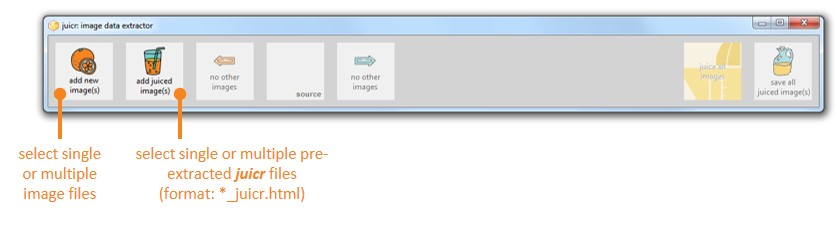

Images can be loaded into **juicr** using the *add new image(s)* button. Alternatively one or many images (as a vector of file name strings) can be included via console:

```r
# then load juicr
library(juicr)
GUI_juicr("Kam_et_al_2003_Fig2.jpg")
# or many files
GUI_juicr(c("Kam_et_al_2003_Fig2.jpg", "Kortum_and_Acymyan_2013_Fig4.jpg"))
```

If an image is loaded, the main window will look like this:

[figure not shown]

# Automated extraction functionality

The center section of **juicr** includes two options: *automated* or *manual* tools for extracting data. The automated tools include:

[figure not shown]

By pressing the large **juicr-hex** button, it will first determine automatically plot type (e.g., scatter or bar for now), and then begin attempts to extract data from the image. Successes of extractions, such as whether the y-axis was detected, will presented as an orange orange (detected), and failures as gray oranges (not-detected). Also included a suite of semi-automated tinkering options to help **juicr** detect the desired image objects.

# Manual extraction functionality

A large diversity of manual extraction tools are available:

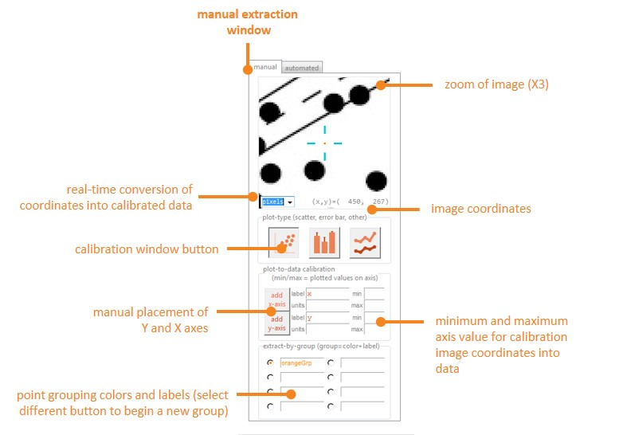

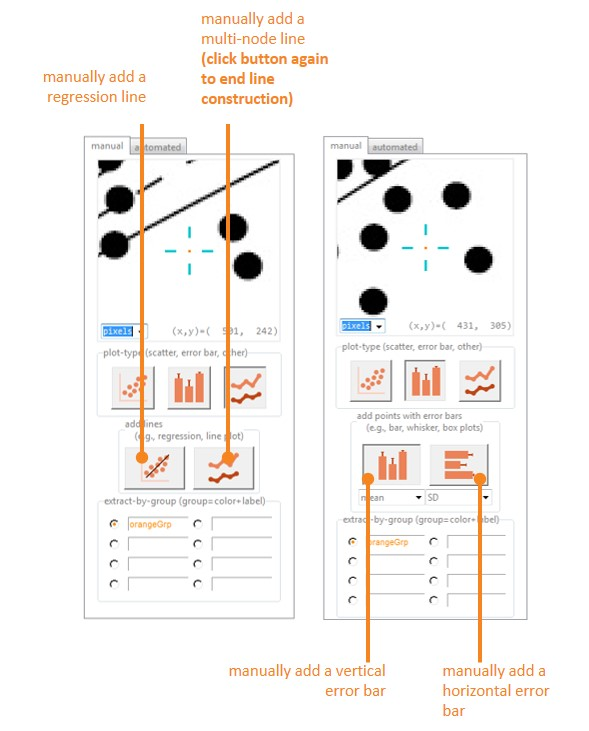

# Saving extractions and generating reports

Currently, **juicr** offers extractions to be saved as .csv files, copied into clipboards, saved as postscript .eps files, or as a fully-embedded and standalone .html file that retains all information of extractions, **juicr** setup, and image modifications for permanent and replicable storage of data.

Here is an example of a report:

[figure not shown]